# Practical Machine Learning Project

Marcus A. Streips

February 13, 2015

## Background

Six participants were asked to perform barbell lifts correctly and incorrectly in 5 different ways (A,B,C,D and E). Accelerometer measurements were taken on the belt, forearm, arm, and dumbell. The goal of this project is to use the data gathered from the experiment to predict the manner in which the six participants did the exercise. A random forest model is proposed, tested and used to predict the activities using a testing data set with the activity (“classe” variable) redacted. The results are presented.

More information is available from the website http://groupware.les.inf.puc-rio.br/har.

### Load libraries, set seed, and activate parallel processing

```r
library(caret)
library(RANN)
library(dplyr)
setwd("~/Google Drive/Coursera/Machine Learning/Project")
set.seed(383838)

#parallel processing
library(doMC)
registerDoMC(cores = 4)
```

### Import Testing and Training Data

```r
training <- read.csv("pml-training.csv", header=TRUE,
                     na.strings=c("", " ","#DIV/0!"))
testing <- read.csv("pml-testing.csv", header=TRUE, na.strings=c("", " ", "#DIV/0!"))
```

## Pre-Processing

An extensive effort was made to preprocess the data to optimize the model to include:

- Imputation
- Eliminating Near Zero Value Variables
- PCA
- Removing Highly Correlated Predictors
- Standardizing Data with Center and Scale

It was determined that these pre-processing steps were unneccesary to develop a highly accurate model and so they are not presented here.

Data that was not continuous was removed as well as all variables lacking data in the testing data set.

```r
#Remove Unnessary fields and fields with all NAs
new_names <- sapply(testing[,1:160], mean)
na_fields <- as.data.frame(new_names, row.names=NULL)
na_fields$names <- rownames(na_fields)
fields <- filter(na_fields, new_names != "NA")
new_fields <- as.vector(fields[,2])
new_fields_sm <- new_fields[5:56]

new_testing <- testing[new_fields_sm]
new_training <- training[new_fields_sm]

#format all data as numeric
new_testing <- as.data.frame(lapply(new_testing, as.numeric))
new_training <- as.data.frame(lapply(new_training, as.numeric))

#add back classe to training
new_training$classe <- training$classe
```

## Partitioning

The training data was partitioned so it could be used to build a prediction model.

```r
inTrain <- createDataPartition(y=new_training$classe, p=0.75, list=FALSE)
train <- new_training[inTrain,]
test <- new_training[-inTrain,]
```

## Cross-Validation

A k-fold cross validation with k=3 was chosen over bootstrapping because it was less computationally demanding. Three folds were sufficient do cross validate a highly accurate rf model. A smaller k has more bias, but less variance.

```r
#crossValidation
train_control <- trainControl(method="cv", number=3)
```

## Training the Model

A random forest was chosen for the model because it is one of the most accurate models in Kaggle competitions and incorporates its own internal cross-validation. It performed better than the following models which are not presented here:

- rpart
- naive bayes
- gradient boosing machine

```r
# train the model
model <- train(classe~., data=train, trControl=train_control, method="rf")
```

## Predict from the Model

The random forest model is used to run predictions on the training partition and testing partition. Using the `confusionMatrix` function from the `caret` package we are able to determine our model’s accuracy.

```r
#predict on training partion
predict <- predict(model,train)
confusionMatrix(predict, train$classe)
```

```
## Confusion Matrix and Statistics
##
##           Reference
## Prediction    A    B    C    D    E
##          A 4185    0    0    0    0
##          B    0 2848    0    0    0
##          C    0    0 2567    0    0
##          D    0    0    0 2412    0
##          E    0    0    0    0 2706
##
## Overall Statistics
##
##                Accuracy : 1
##                  95% CI : (0.9997, 1)
##     No Information Rate : 0.2843
##     P-Value [Acc > NIR] : < 2.2e-16
##
##                   Kappa : 1
##  Mcnemar's Test P-Value : NA
##
## Statistics by Class:
##
##                      Class: A Class: B Class: C Class: D Class: E
## Sensitivity            1.0000   1.0000   1.0000   1.0000   1.0000
## Specificity            1.0000   1.0000   1.0000   1.0000   1.0000
## Pos Pred Value         1.0000   1.0000   1.0000   1.0000   1.0000
## Neg Pred Value         1.0000   1.0000   1.0000   1.0000   1.0000
## Prevalence             0.2843   0.1935   0.1744   0.1639   0.1839
## Detection Rate         0.2843   0.1935   0.1744   0.1639   0.1839
## Detection Prevalence   0.2843   0.1935   0.1744   0.1639   0.1839
## Balanced Accuracy      1.0000   1.0000   1.0000   1.0000   1.0000
```

```r
#predict on testing partition
predict2 <- predict(model, test)
confusionMatrix(predict2, test$classe)
```

```
## Confusion Matrix and Statistics
##
##           Reference
## Prediction    A    B    C    D    E
##          A 1394    8    0    0    0
##          B    0  937    5    1    1
##          C    1    4  849    7    3
##          D    0    0    1  794    2
##          E    0    0    0    2  895
##
## Overall Statistics
##
##                Accuracy : 0.9929
##                  95% CI : (0.9901, 0.995)
##     No Information Rate : 0.2845
##     P-Value [Acc > NIR] : < 2.2e-16
##
##                   Kappa : 0.991
##  Mcnemar's Test P-Value : NA
##
## Statistics by Class:
##
##                      Class: A Class: B Class: C Class: D Class: E
## Sensitivity            0.9993   0.9874   0.9930   0.9876   0.9933
## Specificity            0.9977   0.9982   0.9963   0.9993   0.9995
## Pos Pred Value         0.9943   0.9926   0.9826   0.9962   0.9978
## Neg Pred Value         0.9997   0.9970   0.9985   0.9976   0.9985
## Prevalence             0.2845   0.1935   0.1743   0.1639   0.1837
## Detection Rate         0.2843   0.1911   0.1731   0.1619   0.1825
## Detection Prevalence   0.2859   0.1925   0.1762   0.1625   0.1829
## Balanced Accuracy      0.9985   0.9928   0.9946   0.9934   0.9964
```

## Expectation for Out-of-Sample Error

```r
#error rate
missClass = function(values, prediction) {
        sum(prediction != values)/length(values)
}
errRate = missClass(test$classe, predict2) #same as 1-0.9929
errRate
```

```
## [1] 0.007137031
```

## Estimating Error with Cross-Validation

Using the K(3)-folds cross validation we see the resampling results across the tuning parameters and the corresponding accuracies, the inverse of which would be the errors.

```r
model
```

```
## Random Forest
##
## 14718 samples
##    52 predictor
##     5 classes: 'A', 'B', 'C', 'D', 'E'
##
## No pre-processing
## Resampling: Cross-Validated (3 fold)
##
## Summary of sample sizes: 9811, 9812, 9813
##
## Resampling results across tuning parameters:
##
##   mtry  Accuracy   Kappa      Accuracy SD  Kappa SD
##    2    0.9869546  0.9834966  0.001414349  0.001791680
##   27    0.9897404  0.9870213  0.001005669  0.001273931
##   52    0.9848481  0.9808307  0.002785539  0.003526016
##
## Accuracy was used to select the optimal model using  the largest value.
## The final value used for the model was mtry = 27.
```

## Analyzing Model

Using the `varImp` function of the `caret` package we can review our model to determine which variable were the most important in making our predicitions with an accuracy of 99.29%.

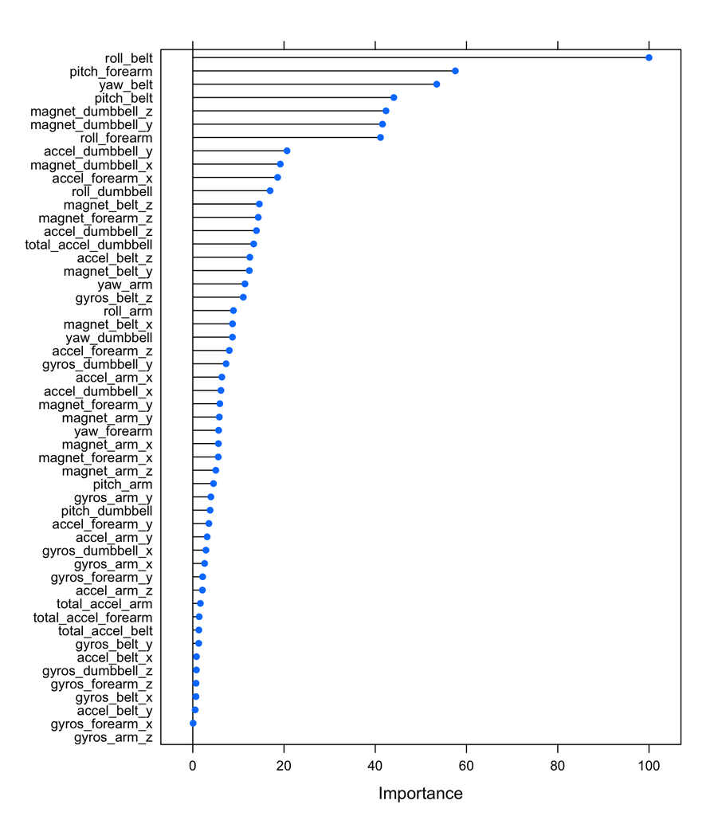

```r
#plotting importance of variables
varImpObj <- varImp(model)
plot(varImpObj)
```